# Roman_zadanie_domowe__modul_4_1

## O Danych

Zbiór danych zawiera informacje o trzech gatunkach irysów: Iris setosa, Iris versicolor, i Iris virginica.

Dane obejmują pomiary czterech cech: długość i szerokość działki kielicha oraz długość i szerokość płatka.

Każdy wiersz w zbiorze danych reprezentuje pojedynczy kwiat, a wartości pomiarów są podane w centymetrach.

Zbiór składa się z 150 próbek, po 50 dla każdego gatunku, i jest szeroko stosowany jako podstawowy zbiór danych do testowania algorytmów klasyfikacji oraz w nauce o danych i uczeniu maszynowym.

Kolumny:

- **długość kielicha (sepal length)** - Długość kielicha w cm
- **szerokość kielicha (sepal width)** - Szerokość kielicha w cm
- **długość płatka (petal length)** - Długość płatka w cm
- **szerokość płatka (petal width)** - Szerokość płatka w cm
- **klasa (class)** - Klasa irysa (setosa, versicolor, virginica)

# Analiza 3 Gatunków Irysa

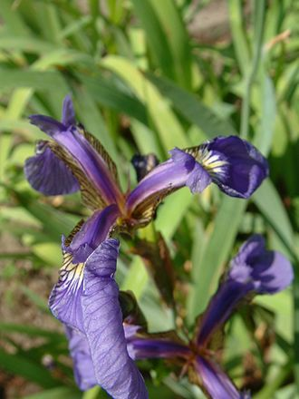

## Iris Setosa

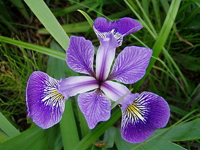

## Iris Versicolor

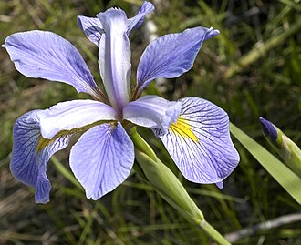

## Na podstawie 150 próbek trzech gatunków Irysa przeprowadzimy analizę wielkości oraz szerokości łodygi jak i płatka.

|  | długość kielicha (sepal length) | szerokość kielicha (sepal width) | długość płatka (petal length) | szerokość płatka (petal width) | klasa (class) |
| --- | --- | --- | --- | --- | --- |
| 0 | 5.1 | 3.5 | 1.4 | 0.2 | Iris-setosa |
| 1 | 4.9 | 3.0 | 1.4 | 0.2 | Iris-setosa |
| 2 | 4.7 | 3.2 | 1.3 | 0.2 | Iris-setosa |
| 3 | 4.6 | 3.1 | 1.5 | 0.2 | Iris-setosa |
| 4 | 5.0 | 3.6 | 1.4 | 0.2 | Iris-setosa |
| ... | ... | ... | ... | ... | ... |
| 145 | 6.7 | 3.0 | 5.2 | 2.3 | Iris-virginica |
| 146 | 6.3 | 2.5 | 5.0 | 1.9 | Iris-virginica |
| 147 | 6.5 | 3.0 | 5.2 | 2.0 | Iris-virginica |
| 148 | 6.2 | 3.4 | 5.4 | 2.3 | Iris-virginica |
| 149 | 5.9 | 3.0 | 5.1 | 1.8 | Iris-virginica |

150 rows × 5 columns

### Wyświetlamy podstawowe statystyki.

|  | długość kielicha (sepal length) | szerokość kielicha (sepal width) | długość płatka (petal length) | szerokość płatka (petal width) |
| --- | --- | --- | --- | --- |
| count | 150.000000 | 150.000000 | 150.000000 | 150.000000 |
| mean | 5.843333 | 3.054000 | 3.758667 | 1.198667 |
| std | 0.828066 | 0.433594 | 1.764420 | 0.763161 |
| min | 4.300000 | 2.000000 | 1.000000 | 0.100000 |
| 25% | 5.100000 | 2.800000 | 1.600000 | 0.300000 |
| 50% | 5.800000 | 3.000000 | 4.350000 | 1.300000 |
| 75% | 6.400000 | 3.300000 | 5.100000 | 1.800000 |
| max | 7.900000 | 4.400000 | 6.900000 | 2.500000 |

### Jako że są tyko trzy typy tej rośliny sprawdzamy czy dane są dla każdej klasy są tej samej wartości.

```
klasa (class)
Iris-setosa        50
Iris-versicolor    50
Iris-virginica     50
Name: count, dtype: int64
```

### Jako że mamy równo po 50 sztuk danych dla każdej klasy. Przystępujemy do analizy wizualnej żeby informacje były jak najbardziej szczegółowe nie wybieramy losowych tylko analizujemy wszystko.

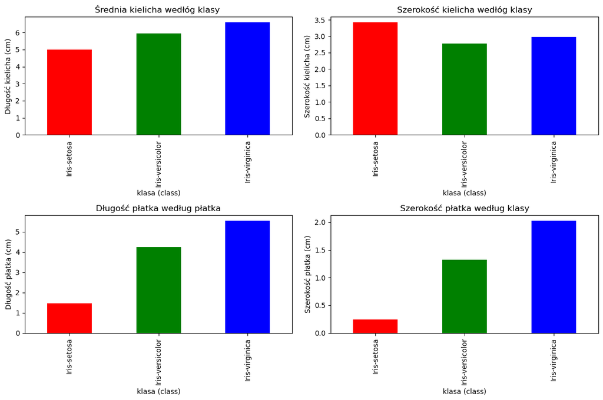

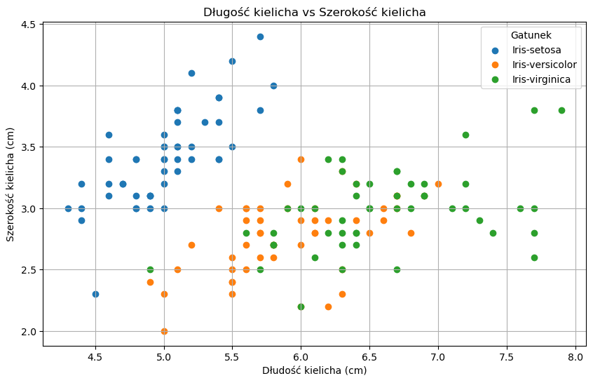

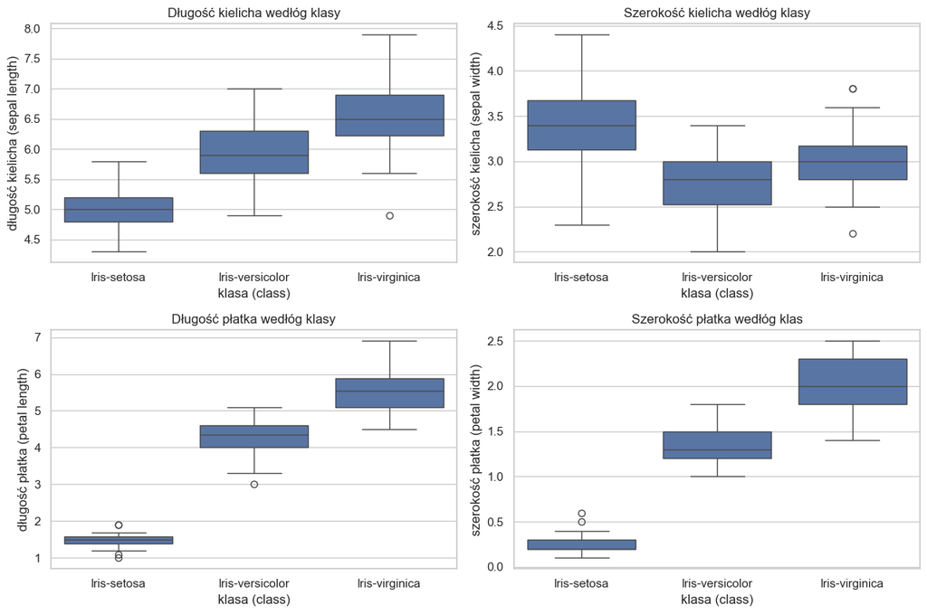

### Widzimy że dane są spójne z małymi odchyłami. Mimo tych małych wartości odstających informacje są wiarygodne.

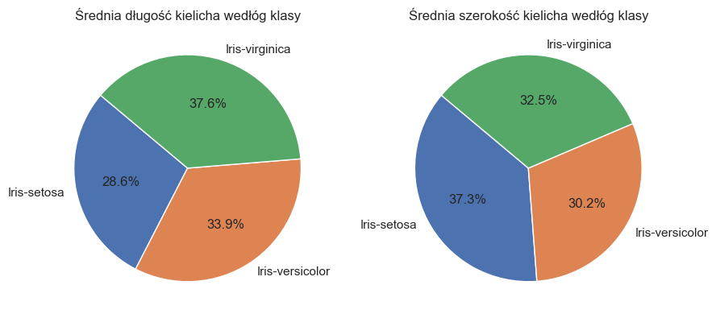

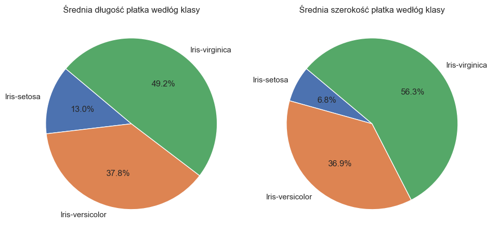

### Ten wykres wpełni obrazuje nam wielkości poszczególnych Irysów.

# Wnioski końcowe :

## Iris Sentosa

```
- jest najmniejszy z tego gatunku,
- ma płatki i wielkość kielicha o charakterystycznych wymiarach
```

## Iris Versicolor

```
- jest średniej wielkości,
- ma płatki i wielkość kielicha o wymiarach pośrednich między Iris Setosa i Iris Virginica,
- płatki są proporcjonalnie krótsze niż u Iris Virginica
```

## Iris Virginica

```
- jest zazwyczaj większa od pozostałych gatunków,
- ma płatki i wielkość kielicha o wymiarach różniących się od pozostałych gatunków,
- płatki środkowe są od 2/3 do prawie tak długie jak wielkość kielicha
```